# Conditional Probability

Yuanting Lu

09/24/2025

### Conditional Probability

The probability that event $B$ will occur given the knowledge that an event $A$ has already occurred is a **conditional probability**, denoted by $P(B|A)$ and read as “**the probability of $B$ given $A$**”.

$$P(B|A) = \dfrac{P(A \cap B)}{P(A)} =
\dfrac{\#(A \cap B)}{\#A}.$$

**Example 1.** Consider the experiment of rolling a pair of fair dice.

1. Find the probability that the sum is 10, given that the first die lands on 4.
2. Find the probability that the sum is 7, given that the first die lands on 4.

**Example 2.** The Triple Blood Test screens a pregnant woman and provides as estimated risk of her baby being born with the genetic disorder Down syndrome.[^1] A study[^2] of 5282 women aged 35 or over analyzed the Triple Blood Test to test its accuracy. The result is shown in the table.

|  | Down Syndrome | Unaffected | Total |
| --- | --- | --- | --- |
| Test Positive (+) | 48 | 1307 |  |
| Test Negative (-) | 6 | 3921 |  |
| Total |  |  | 5282 |

Let $D$ denote Down Syndrome.

1. The term sensitivity refers to the probability $P(+|D)$.
2. The term specificity refers to the probability $P(-|D^c)$.
3. The false positive rate refers to $P(+|D^c)$ and the false negative rate is $P(-|D)$.
4. Interpret the conditional probabilities: $P(D^c|+)$ and $P(D|-)$.
5. In part c and d, which one(s) might be the biggest concern?

**Example 3.** A person is accused of crime because the person’s DNA matches the DNA at a crime scene (found through database of DNA). Only 1 in a million people have this specific DNA. Given there are about 6 million people in the local area, is the person surely guilty? (Note: Only one person is guilty.)

|  | Guilty | Innocent | Total |
| --- | --- | --- | --- |
| DNA Match |  |  |  |
| DNA Doesn't Match |  |  |  |
| Total |  |  |  |

1. Find $P(\mbox{DNA match | Innocent})$.
2. Find $P(\mbox{Innocent | DNA match})$.
3. Which conditional probability works for the district attorney?
4. Which conditional probability works for the defense lawyer?

### Multiplication Rule

$$P(A \cap B) = P(B|A)\cdot P(A)$$
$$P(A \cap B) = P(A|B)\cdot P(B)$$

**Example 4**

Suppose that two chips are randomly chosen from a box of 4 red and 6 blue chips

1. What is the probability that both are red?
2. What is the probability that one is red and the other is blue?

### Independent Events

Event $A$ and $B$ are **independent** if the occurrence of one does not affect the occurrence of the other. In terms of probability, this means

- $P(A|B) = P(A)$.
- $P(B|A) = P(B)$.
- $P(A\cap B) = P(A)\cdot P(B)$.

**Example 5.** Assume a sample space has 18 outcomes (18 boxes on the graph). Are the red event and the blue event independent?

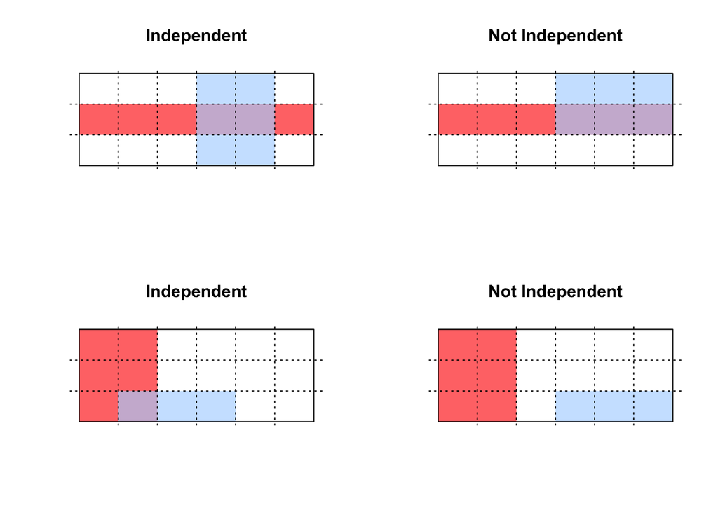

**Example 6.** Consider the experiment of rolling a pair of fair dice. Are getting a sum of 10 and the first die lands on 4 independent?

**Example 7.** Again consider the experiment of rolling a pair of fair dice. Are getting a sum of 7 and the first die lands on 4 independent?

[^1]: A. Agresti, C. Franklin, *it Statistics, the Art and Science of Learning from Data*, pp. 232.
[^2]: J. Haddow et al., *New England Journal of Medicine*, vol. 330, pp. 1114–1118, 1994.